# predict-future-sales-eda_01

## 캐글 대회 입문하기

### 대회 개요

- 대회명 : 미래 판매 예측
  - '데이터 과학 대회에서 우승하는 방법' Coursera 과정의 최종 프로젝트 대회
- 참여팀 : 2020/09/06 현재 8562개팀
- 데이터 : 러시아 최대 소프트웨어 회사 중 하나 인 1C Company 에서 친절하게 제공 한 일일 판매 데이터
- 우리의 과제 : 다음달의 모든 제품 및 매장에 대한 총 매출을 예측하기
- 평가지표 : 평균 제곱근 오차(RMSE)

### 제공된 데이터 위치 확인

```python
import numpy as np # linear algebra
import pandas as pd # data processing, CSV file I/O (e.g. pd.read_csv)

import os
for dirname, _, filenames in os.walk('/kaggle/input'):
    for filename in filenames:
        print(os.path.join(dirname, filename))
```

```
/kaggle/input/competitive-data-science-predict-future-sales/items.csv
/kaggle/input/competitive-data-science-predict-future-sales/sample_submission.csv
/kaggle/input/competitive-data-science-predict-future-sales/item_categories.csv
/kaggle/input/competitive-data-science-predict-future-sales/sales_train.csv
/kaggle/input/competitive-data-science-predict-future-sales/shops.csv
/kaggle/input/competitive-data-science-predict-future-sales/test.csv
```

### 파일 설명

- sales_train.csv : 학습 데이터. 2013년 1월부터 2015년 10월까지의 일일 기록 데이터.
- test.csv - 테스트 데이터. 상점과 제품의 2015년 11월 매출을 예측.
- sample_submission.csv : 올바른 형식의 샘플 파일 제출
- items.csv : 항목/제품에 대한 추가 정보
- item_categories.csv : 항목 카테고리에 대한 추가 정보
- shops.csv : 상점에 대한 추가 정보

```python
train = pd.read_csv("/kaggle/input/competitive-data-science-predict-future-sales/sales_train.csv")
sub= pd.read_csv("/kaggle/input/competitive-data-science-predict-future-sales/sample_submission.csv")
test = pd.read_csv("/kaggle/input/competitive-data-science-predict-future-sales/test.csv")
```

## 기본 데이터 탐색

```python
print("학습용 데이터 행열 : {}".format(train.shape))
print("제출용 데이터 행열 : {}".format(sub.shape))
print("테스트 데이터 행열 : {}".format(test.shape))
```

```
학습용 데이터 행열 : (2935849, 6)
제출용 데이터 행열 : (214200, 2)
테스트 데이터 행열 : (214200, 3)
```

```python
train.info()
```

```
<class 'pandas.core.frame.DataFrame'>
RangeIndex: 2935849 entries, 0 to 2935848
Data columns (total 6 columns):
 #   Column          Dtype
---  ------          -----
 0   date            object
 1   date_block_num  int64
 2   shop_id         int64
 3   item_id         int64
 4   item_price      float64
 5   item_cnt_day    float64
dtypes: float64(2), int64(3), object(1)
memory usage: 134.4+ MB
```

```python
test.info()
```

```
<class 'pandas.core.frame.DataFrame'>
RangeIndex: 214200 entries, 0 to 214199
Data columns (total 3 columns):
 #   Column   Non-Null Count   Dtype
---  ------   --------------   -----
 0   ID       214200 non-null  int64
 1   shop_id  214200 non-null  int64
 2   item_id  214200 non-null  int64
dtypes: int64(3)
memory usage: 4.9 MB
```

```python
sub.info()
```

```
<class 'pandas.core.frame.DataFrame'>
RangeIndex: 214200 entries, 0 to 214199
Data columns (total 2 columns):
 #   Column          Non-Null Count   Dtype
---  ------          --------------   -----
 0   ID              214200 non-null  int64
 1   item_cnt_month  214200 non-null  float64
dtypes: float64(1), int64(1)
memory usage: 3.3 MB
```

### 데이터 필드 설명

- ID- 테스트 세트 내에서 (Shop, Item) 튜플을 나타내는 Id
- shop_id- 상점의 고유 식별자
- item_id- 상품의 고유 식별자
- item_category_id- 항목 카테고리의 고유 식별자
- item_cnt_day- 판매 된 제품 수입니다. 이 측정 값의 월별 금액을 예측하고 있습니다.
- item_price- 상품의 현재 가격
- date -dd / mm / yyyy 형식의 날짜
- date_block_num- 편의를 위해 사용되는 연속 월 번호입니다. 2013 년 1 월은 0, 2013 년 2 월은 1, ..., 2015 년 10 월은 33입니다.
- item_name- 항목 이름
- shop_name- 상점 이름
- item_category_name- 항목 카테고리 이름

```python
train.head()
```

|  | date | date_block_num | shop_id | item_id | item_price | item_cnt_day |
| --- | --- | --- | --- | --- | --- | --- |
| 0 | 02.01.2013 | 0 | 59 | 22154 | 999.00 | 1.0 |
| 1 | 03.01.2013 | 0 | 25 | 2552 | 899.00 | 1.0 |
| 2 | 05.01.2013 | 0 | 25 | 2552 | 899.00 | -1.0 |
| 3 | 06.01.2013 | 0 | 25 | 2554 | 1709.05 | 1.0 |
| 4 | 15.01.2013 | 0 | 25 | 2555 | 1099.00 | 1.0 |

```python
test.head()
```

|  | ID | shop_id | item_id |
| --- | --- | --- | --- |
| 0 | 0 | 5 | 5037 |
| 1 | 1 | 5 | 5320 |
| 2 | 2 | 5 | 5233 |
| 3 | 3 | 5 | 5232 |
| 4 | 4 | 5 | 5268 |

```python
print(sub.head())
print(sub.item_cnt_month.describe())
```

```
   ID  item_cnt_month
0   0             0.5
1   1             0.5
2   2             0.5
3   3             0.5
4   4             0.5
count    214200.0
mean          0.5
std           0.0
min           0.5
25%           0.5
50%           0.5
75%           0.5
max           0.5
Name: item_cnt_month, dtype: float64
```

```python
print(train['item_cnt_day'].describe())
```

```
count    2.935849e+06
mean     1.242641e+00
std      2.618834e+00
min     -2.200000e+01
25%      1.000000e+00
50%      1.000000e+00
75%      1.000000e+00
max      2.169000e+03
Name: item_cnt_day, dtype: float64
```

```python
import matplotlib.pyplot as plt
import seaborn as sns
from sklearn.model_selection import train_test_split
```

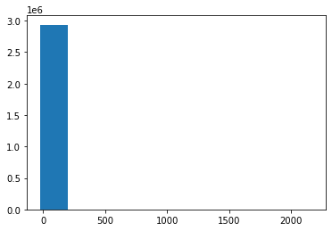

```python
plt.hist(train['item_cnt_day'])
```

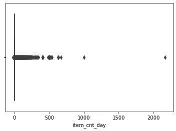

```python
sns.boxplot(train['item_cnt_day'])
```

```python
### 날짜 변환
train['date'] = pd.to_datetime(train['date'],format = '%d.%m.%Y')
```

```python
train['year'] = train['date'].dt.year
train['month'] = train['date'].dt.month
```

```python
train
```

|  | date | date_block_num | shop_id | item_id | item_price | item_cnt_day | year | month |
| --- | --- | --- | --- | --- | --- | --- | --- | --- |
| 0 | 2013-01-02 | 0 | 59 | 22154 | 999.00 | 1.0 | 2013 | 1 |
| 1 | 2013-01-03 | 0 | 25 | 2552 | 899.00 | 1.0 | 2013 | 1 |
| 2 | 2013-01-05 | 0 | 25 | 2552 | 899.00 | -1.0 | 2013 | 1 |
| 3 | 2013-01-06 | 0 | 25 | 2554 | 1709.05 | 1.0 | 2013 | 1 |
| 4 | 2013-01-15 | 0 | 25 | 2555 | 1099.00 | 1.0 | 2013 | 1 |
| ... | ... | ... | ... | ... | ... | ... | ... | ... |
| 2935844 | 2015-10-10 | 33 | 25 | 7409 | 299.00 | 1.0 | 2015 | 10 |
| 2935845 | 2015-10-09 | 33 | 25 | 7460 | 299.00 | 1.0 | 2015 | 10 |
| 2935846 | 2015-10-14 | 33 | 25 | 7459 | 349.00 | 1.0 | 2015 | 10 |
| 2935847 | 2015-10-22 | 33 | 25 | 7440 | 299.00 | 1.0 | 2015 | 10 |
| 2935848 | 2015-10-03 | 33 | 25 | 7460 | 299.00 | 1.0 | 2015 | 10 |

2935849 rows × 8 columns

```python
sum_train = train.groupby( ['year', 'month'] ).sum()
sum_train = sum_train.drop(['date_block_num', 'shop_id', 'item_id', 'item_price'], axis=1)
sum_train
```

| year | month | item_cnt_day |
| --- | --- | --- |
| 2013 | 1 | 131479.0 |
|  | 2 | 128090.0 |
|  | 3 | 147142.0 |
|  | 4 | 107190.0 |
|  | 5 | 106970.0 |
|  | 6 | 125381.0 |
|  | 7 | 116966.0 |
|  | 8 | 125291.0 |
|  | 9 | 133332.0 |
|  | 10 | 127541.0 |
|  | 11 | 130009.0 |
|  | 12 | 183342.0 |
| 2014 | 1 | 116899.0 |
|  | 2 | 109687.0 |
|  | 3 | 115297.0 |
|  | 4 | 96556.0 |
|  | 5 | 97790.0 |
|  | 6 | 97429.0 |
|  | 7 | 91280.0 |
|  | 8 | 102721.0 |
|  | 9 | 99208.0 |
|  | 10 | 107422.0 |
|  | 11 | 117845.0 |
|  | 12 | 168755.0 |
| 2015 | 1 | 110971.0 |
|  | 2 | 84198.0 |
|  | 3 | 82014.0 |
|  | 4 | 77827.0 |
|  | 5 | 72295.0 |
|  | 6 | 64114.0 |
|  | 7 | 63187.0 |
|  | 8 | 66079.0 |
|  | 9 | 72843.0 |
|  | 10 | 71056.0 |

```python
sum_train.columns = ['all_item_cnt_month']
sum_train.columns
```

```
Index(['all_item_cnt_month'], dtype='object')
```

```python
train_df = pd.merge(left=train, right=sum_train, how='left', on=['year', 'month'], sort=False)
train_df
```

|  | date | date_block_num | shop_id | item_id | item_price | item_cnt_day | year | month | all_item_cnt_month |
| --- | --- | --- | --- | --- | --- | --- | --- | --- | --- |
| 0 | 2013-01-02 | 0 | 59 | 22154 | 999.00 | 1.0 | 2013 | 1 | 131479.0 |
| 1 | 2013-01-03 | 0 | 25 | 2552 | 899.00 | 1.0 | 2013 | 1 | 131479.0 |
| 2 | 2013-01-05 | 0 | 25 | 2552 | 899.00 | -1.0 | 2013 | 1 | 131479.0 |
| 3 | 2013-01-06 | 0 | 25 | 2554 | 1709.05 | 1.0 | 2013 | 1 | 131479.0 |
| 4 | 2013-01-15 | 0 | 25 | 2555 | 1099.00 | 1.0 | 2013 | 1 | 131479.0 |
| ... | ... | ... | ... | ... | ... | ... | ... | ... | ... |
| 2935844 | 2015-10-10 | 33 | 25 | 7409 | 299.00 | 1.0 | 2015 | 10 | 71056.0 |
| 2935845 | 2015-10-09 | 33 | 25 | 7460 | 299.00 | 1.0 | 2015 | 10 | 71056.0 |
| 2935846 | 2015-10-14 | 33 | 25 | 7459 | 349.00 | 1.0 | 2015 | 10 | 71056.0 |
| 2935847 | 2015-10-22 | 33 | 25 | 7440 | 299.00 | 1.0 | 2015 | 10 | 71056.0 |
| 2935848 | 2015-10-03 | 33 | 25 | 7460 | 299.00 | 1.0 | 2015 | 10 | 71056.0 |

2935849 rows × 9 columns

```python
test.head()
```

|  | ID | shop_id | item_id |
| --- | --- | --- | --- |
| 0 | 0 | 5 | 5037 |
| 1 | 1 | 5 | 5320 |
| 2 | 2 | 5 | 5233 |
| 3 | 3 | 5 | 5232 |
| 4 | 4 | 5 | 5268 |

```python
# 변수 선택 및 데이터 지정
sel_f = ['shop_id', 'item_id']
X_train = train_df[sel_f]
X_test = test[sel_f]
```

```python
label = "all_item_cnt_month"
y_train = train_df[label]
```

### 모델 만들기

```python
from sklearn.linear_model import LinearRegression
```

```python
model = LinearRegression()  # 모델 생성
model.fit(X_train, y_train)  # 모델 훈련
pred = model.predict(X_test) # 모델로 예측
pred
```

```
array([115018.02904017, 114996.78432021, 115003.31538253, ...,
       113826.66240028, 113534.56626825, 114936.79285528])
```

```python
sub.columns
```

```
Index(['ID', 'item_cnt_month'], dtype='object')
```

```python
sub['item_cnt_month'] = pred
sub
```

|  | ID | item_cnt_month |
| --- | --- | --- |
| 0 | 0 | 115018.029040 |
| 1 | 1 | 114996.784320 |
| 2 | 2 | 115003.315383 |
| 3 | 3 | 115003.390452 |
| 4 | 4 | 115000.687944 |
| ... | ... | ... |
| 214195 | 214195 | 113624.199468 |
| 214196 | 214196 | 113794.307367 |
| 214197 | 214197 | 113826.662400 |
| 214198 | 214198 | 113534.566268 |
| 214199 | 214199 | 114936.792855 |

214200 rows × 2 columns

### 제출

```python
sub.to_csv("firstSub.csv", index=False)
```

### shop_id, item_id 별 월별 합계

```python
# item_cnt_day : 판매된 제품수, item_price : 총 합계 금액
sum_train = train.groupby( ['year', 'month', 'shop_id', 'item_id'] ).sum()
sum_train = sum_train.drop(['date_block_num'], axis=1)
sum_train
```

| year | month | shop_id | item_id | item_price | item_cnt_day |
| --- | --- | --- | --- | --- | --- |
| 2013 | 1 | 0 | 32 | 884.0 | 6.0 |
|  |  |  | 33 | 1041.0 | 3.0 |
|  |  |  | 35 | 247.0 | 1.0 |
|  |  |  | 43 | 221.0 | 1.0 |
|  |  |  | 51 | 257.0 | 2.0 |
| ... | ... | ... | ... | ... | ... |
| 2015 | 10 | 59 | 22087 | 357.0 | 6.0 |
|  |  |  | 22088 | 238.0 | 2.0 |
|  |  |  | 22091 | 179.0 | 1.0 |
|  |  |  | 22100 | 629.0 | 1.0 |
|  |  |  | 22102 | 1250.0 | 1.0 |

1609124 rows × 2 columns

```python
sum_train.columns = ['shop_item_price_month', 'shop_item_cnt_month']
sum_train.columns
```

```
Index(['shop_item_price_month', 'shop_item_cnt_month'], dtype='object')
```

```python
train_df = pd.merge(left=train,
                    right=sum_train,
                    how='left', on=['year', 'month', 'shop_id', 'item_id'], sort=False)
train_df
```

|  | date | date_block_num | shop_id | item_id | item_price | item_cnt_day | year | month | shop_item_price_month | shop_item_cnt_month |
| --- | --- | --- | --- | --- | --- | --- | --- | --- | --- | --- |
| 0 | 2013-01-02 | 0 | 59 | 22154 | 999.00 | 1.0 | 2013 | 1 | 999.00 | 1.0 |
| 1 | 2013-01-03 | 0 | 25 | 2552 | 899.00 | 1.0 | 2013 | 1 | 1798.00 | 0.0 |
| 2 | 2013-01-05 | 0 | 25 | 2552 | 899.00 | -1.0 | 2013 | 1 | 1798.00 | 0.0 |
| 3 | 2013-01-06 | 0 | 25 | 2554 | 1709.05 | 1.0 | 2013 | 1 | 1709.05 | 1.0 |
| 4 | 2013-01-15 | 0 | 25 | 2555 | 1099.00 | 1.0 | 2013 | 1 | 1099.00 | 1.0 |
| ... | ... | ... | ... | ... | ... | ... | ... | ... | ... | ... |
| 2935844 | 2015-10-10 | 33 | 25 | 7409 | 299.00 | 1.0 | 2015 | 10 | 897.00 | 3.0 |
| 2935845 | 2015-10-09 | 33 | 25 | 7460 | 299.00 | 1.0 | 2015 | 10 | 897.00 | 3.0 |
| 2935846 | 2015-10-14 | 33 | 25 | 7459 | 349.00 | 1.0 | 2015 | 10 | 349.00 | 1.0 |
| 2935847 | 2015-10-22 | 33 | 25 | 7440 | 299.00 | 1.0 | 2015 | 10 | 299.00 | 1.0 |
| 2935848 | 2015-10-03 | 33 | 25 | 7460 | 299.00 | 1.0 | 2015 | 10 | 897.00 | 3.0 |

2935849 rows × 10 columns

```python
# 변수 선택 및 데이터 지정
sel = ['shop_id', 'item_id']
X_tr_all = train_df[sel]
X_test_all = test[sel]

label = "shop_item_cnt_month"
y_tr_all = train_df[label]

X_train, X_test, y_train, y_test = train_test_split(X_tr_all, y_tr_all,
                                                   random_state=77)
```

[output not shown]

```python
model = LinearRegression()  # 모델 생성
model.fit(X_train, y_train)  # 모델 훈련

model.score(X_test, y_test)
```

```
0.004599368506762125
```

```python
sub.to_csv("secondSub.csv", index=False)
```